# Exercise2

# Rozdeleni pravdepodobnosti

```r
library(latexpdf)
library(latex2exp)
```

### Prikazy pro rozdeleni

na zacatku pismeno d, kdyz pravdepodobnosti P(x=i) = pi na zacatku pismeno p, kdyz pravdepodobnost P(X<=i) q je pro qvantil r pro random numbers

## Binomicke rozdeleni (diskretni), Bi(n, p)

n krat opakuju pokus, n - pocet pokusu, p - pravdepodobnost vyskytu jevu v 1 pokusu

### PR

Ucinnost antibiotika je 80 %. Podavame ho 10 pac na oddeleni. Zratajte pravdepodobnosti:

1. vsichni se vyleci P(X=10)

```r
n <- 10
dbinom(10, 10, 0.8)
```

```
[1] 0.1073742
```

2. prave 7 se vyleci P(X=7)

```r
dbinom(7, 10, 0.8)
```

```
[1] 0.2013266
```

4. max 8 se vyleci (P<=8)

```r
pbinom(8, 10, 0.8)
```

```
[1] 0.6241904
```

5. aspon 5 se vyleci (P>=5) stejny jako 1 - P(<=4)

```r
1 - pbinom(4, 10, 0.8)
```

```
[1] 0.9936306
```

```r
pbinom(4, 10, 0.8, lower.tail = F) # pozor na definici
```

```
[1] 0.9936306
```

tabulka rozdeleni pravdepodobnosti

```r
xb <- 0:10
hustotab <- dbinom(xb, 10, 0.8)
(tabulka <- data.frame(hodnota = xb, pravd = hustotab))
```

| hodnota | pravd |
| --- | --- |
| 0 | 0.0000001024 |
| 1 | 0.0000040960 |
| 2 | 0.0000737280 |
| 3 | 0.0007864320 |
| 4 | 0.0055050240 |
| 5 | 0.0264241152 |
| 6 | 0.0880803840 |
| 7 | 0.2013265920 |
| 8 | 0.3019898880 |
| 9 | 0.2684354560 |

[output cut: 1 more lines]

```r
sum(hustotab)
```

```
[1] 1
```

graf rozdeleni pravdepodobnosti

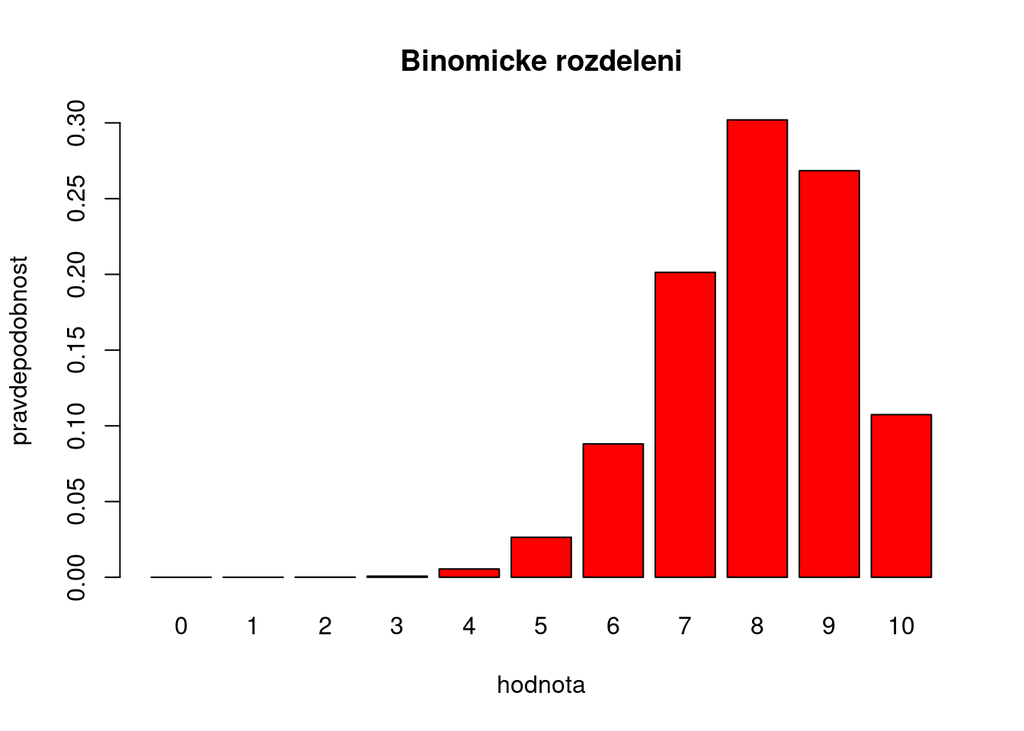

```r
barplot(tabulka$pravd, main = "Binomicke rozdeleni", xlab = "hodnota", ylab = "pravdepodobnost", col = 'red', names.arg = tabulka$hodnota)
```

## Hypergeometricke rozdeleni (diskretni), Hg(m, n, k)

celkem n objektu s vlatnosti A je tam m prvku, z nich vyberu celkem N

da se aproximovat binomickym

### PR

Student se nauci na zkousku 12 z 20. Test obsahuje (nahodny vyber) 5 otazek. m = 12 pocet se sledovanou vlastnosti n = 8 pocet bez lastnosti () k = 5 kolik vyberu celkem objektu

1. student udela zkousku - zodpovi aspon 3 P(X>=3), co je P(X<=2)

```r
phyper(2, 12, 8, 5, lower.tail = F)
```

```
[1] 0.7038184
```

2. student dostane A (vsech 5 dobre)

```r
dhyper(5, 12, 8, 5)
```

```
[1] 0.05108359
```

student neudela zkousku (max 2 otazky), 0, 1, 2

```r
phyper(2, 12, 8, 5)
```

```
[1] 0.2961816
```

```r
xh <- 0:5
hustotah <- dhyper(xh, 12, 8, 5)
(tabulka <- data.frame(hodnota = xh, pravd = hustotah))
```

| hodnota | pravd |
| --- | --- |
| 0 | 0.003611971 |
| 1 | 0.054179567 |
| 2 | 0.238390093 |
| 3 | 0.397316821 |
| 4 | 0.255417957 |
| 5 | 0.051083591 |

```r
sum(hustotah)
```

```
[1] 1
```

## Poissonovo rozdeleni

ma jen jeden parametr lam - stredni hodnota, ocekavana teorie hramad obsluhy ridke jevy

### PR

na samoobsluznou linku 20 lidi za hodinu.

vypocitejte pravd, ze za 15 min prijde 1 clovek. (20/60) * 15

```r
dpois(1, 5)
```

```
[1] 0.03368973
```

za 5 min nikdo neprijde (20/60) * 5

```r
dpois(0, 5 / 3)
```

```
[1] 0.1888756
```

za 10 min aspon 10 lidi (20/60) * 10

```r
ppois(9, 10 / 3, lower.tail = F)
```

```
[1] 0.002356375
```

```r
1 - ppois(9, 10 / 3)
```

```
[1] 0.002356375
```

Tabulka a graf rozd pravd lam = 20 a prvni 20 hodnot

```r
xp <- 0:20
hustotap <- dpois(xp, 20)
(tabulka <- data.frame(hodnota = xp, pravd = hustotap))
```

| hodnota | pravd |
| --- | --- |
| 0 | 2.061154e-09 |
| 1 | 4.122307e-08 |
| 2 | 4.122307e-07 |
| 3 | 2.748205e-06 |
| 4 | 1.374102e-05 |
| 5 | 5.496410e-05 |
| 6 | 1.832137e-04 |
| 7 | 5.234676e-04 |
| 8 | 1.308669e-03 |
| 9 | 2.908153e-03 |

[output cut: 11 more lines]

```r
sum(hustotap)
```

```
[1] 0.5590926
```

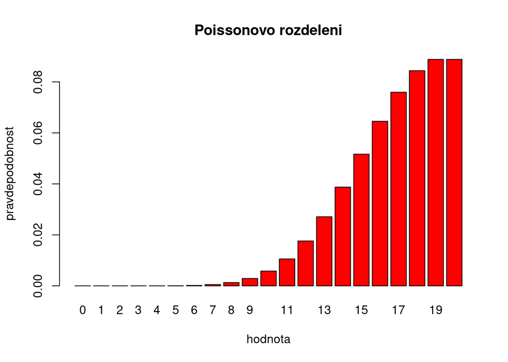

```r
barplot(tabulka$pravd, main = "Poissonovo rozdeleni", xlab = "hodnota", ylab = "pravdepodobnost", col = 'red', names.arg = tabulka$hodnota)
```

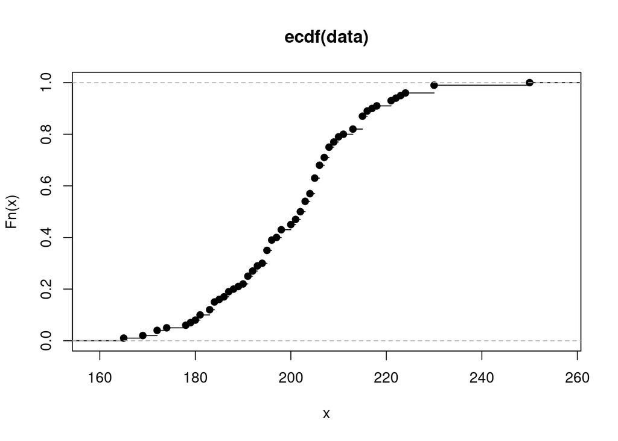

```r
data <- rpois(100, 200)
plot(ecdf(data))
```

## Normalni Gaussovo (spojite) rozdeleni No(stredni, smer odchylka)

pomoci hustoty pravdepodobnosti a smer odchylky

### PR

Zivotnost baterek do mobilu se ridi norm rozdelenim se stredni hodnotou 8 roku a smer odchylkou 2 roky

```r
pnorm(7.5, mean = 8, sd = 2)
```

```
[1] 0.4012937
```

kolik procent baterek vydrzi rozpeti 7 - 9 roku

```r
pnorm(9, mean = 8, sd = 2) - pnorm(7, mean = 8, sd = 2)
```

```
[1] 0.3829249
```

kolik vydrzi vic jak 10 roku

```r
pnorm(10, mean = 8, sd = 2, lower.tail = F)
```

```
[1] 0.1586553
```

```r
1 - pnorm(10, mean = 8, sd = 2)
```

```
[1] 0.1586553
```

za jakou dobu zivotnosti se da zarucit na 90 procent dela se to jako 0.1 kvantil, nebo 0.9 kavntil s false tail

```r
qnorm(0.1, mean = 8, sd = 2)
```

```
[1] 5.436897
```

```r
qnorm(0.9, mean = 8, sd = 2, lower.tail = F)
```

```
[1] 5.436897
```

Histogram a hustota normalneho N(0, 1), je to i normovany

overeni, jestli sou ty data normalni

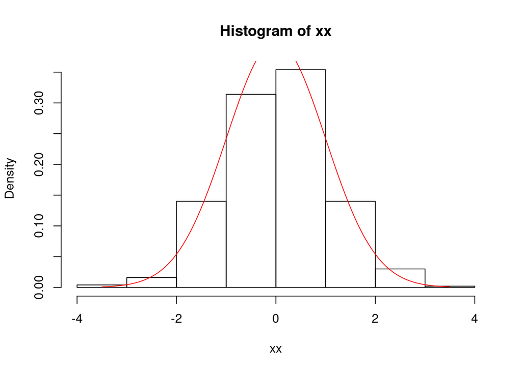

```r
xx <- rnorm(500, 0, 1)
xxx <- seq(-3.5, 3.5, 0.01)
hist(xx, freq = F)
lines(xxx, dnorm(xxx, 0, 1), col="red")
```

## Exponencialni rozdeleni

analogie k poissonovu zivotnost, spolehlivost prevracena lambda

### PR

Delka zivotnosti PC je 2 roky

jaka je pravd, ze PC bude mit zivotnost aspon 1 rok

```r
pexp(1, rate = 1/2, lower.tail = F)
```

```
[1] 0.6065307
```

max 5 roku

```r
pexp(5, rate = 1/2)
```

```
[1] 0.917915
```

S jakou prvad byste se zaruculi s p=0.05 tak dlouho vydrzi jen 5 procent

```r
qexp(0.05, rate = 1/2, lower.tail = F)
```

```
[1] 5.991465
```

Kresleni hustoty

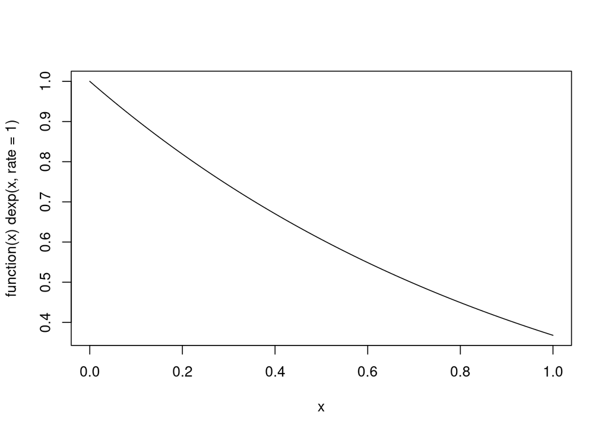

```r
x <- 0:5
plot(function (x) dexp(x, rate = 1))
```

DU v ais zadani